## In-class worksheet, class 18

## 1. Bar plots

*The MASS package contains a data set `bacteria` which contains data from tests of the presence of the bacterium H. influenzae in children with otitis media in the Northern Territory of Australia. We are interested in two columns of this data set: `y` reports presence (`y`) or absence (`n`) of the bacterium. `trt` reports the treatment, which was `placebo`, `drug`, or `drug+` (drug plus high adherence).*

```r
library(MASS)
head(bacteria)
```

```
##   y ap hilo week  ID     trt
## 1 y  p   hi    0 X01 placebo
## 2 y  p   hi    2 X01 placebo
## 3 y  p   hi    4 X01 placebo
## 4 y  p   hi   11 X01 placebo
## 5 y  a   hi    0 X02   drug+
## 6 y  a   hi    2 X02   drug+
```

*Make a bar plot that shows the absolute number of cases with or without the bacterium, stacked on top of each other, for each treatment.*

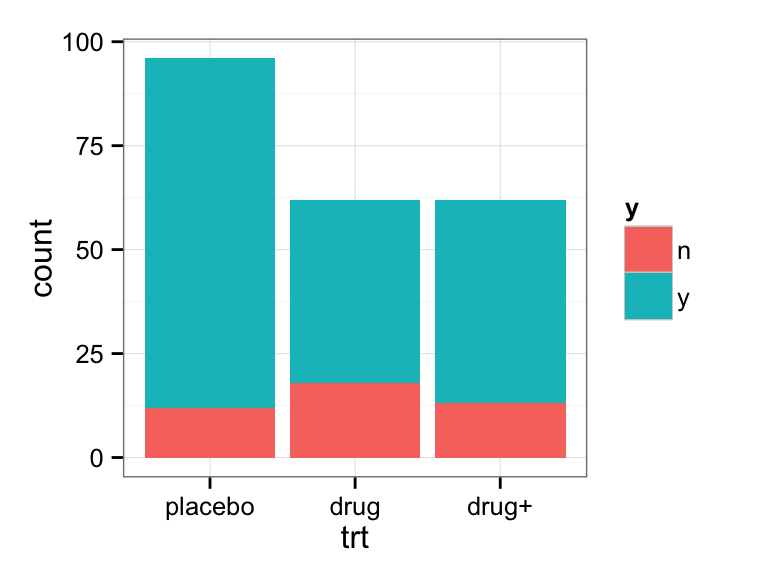

```r
ggplot(bacteria, aes(x=trt, fill=y)) + geom_bar()
```

*Now modify the plot so that bars representing the absolute number of cases with or without the bacterium are shown side-by-side (`position='dodge'`).*

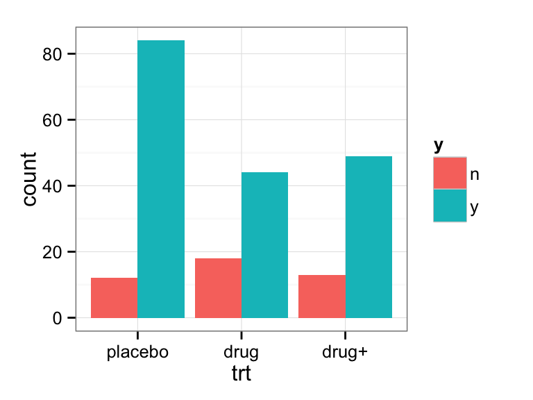

```r
ggplot(bacteria, aes(x=trt, fill=y)) + geom_bar(position='dodge')
```

*Now modify the plot so that bars represent the relative number of cases with or without the bacterium. What is the appropriate `position` option in `geom_bar()` to achieve this effect?*

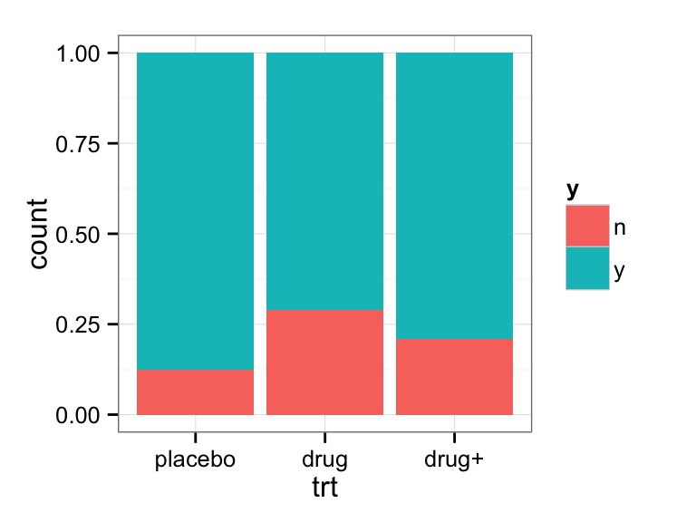

```r
ggplot(bacteria, aes(x=trt, fill=y)) + geom_bar(position='fill')
```

## 2. Histograms and density plots

*Make a histogram plot of sepal lengths in the `iris` data set, using the default histogram settings. Then make two more such plots, with different bin widths. Use `geom_histogram()`*

```
## stat_bin: binwidth defaulted to range/30. Use 'binwidth = x' to adjust this.
```

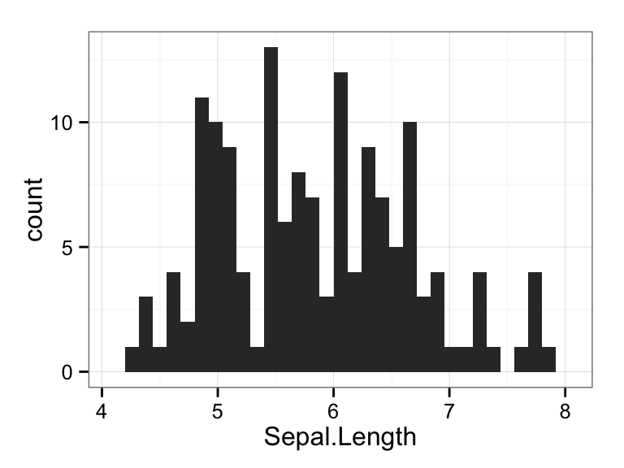

```r
# default settings
ggplot(iris, aes(x=Sepal.Length)) + geom_histogram()
```

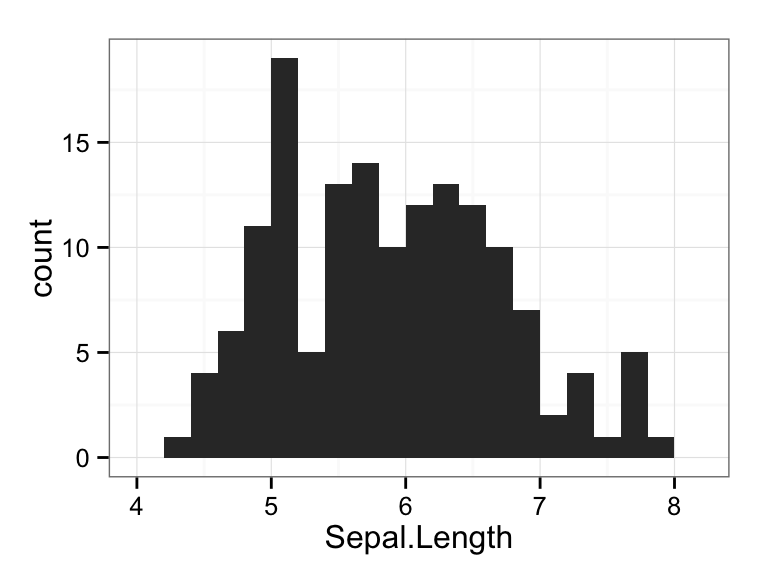

```r
# wider bins
ggplot(iris, aes(x=Sepal.Length)) + geom_histogram(binwidth=.2)
```

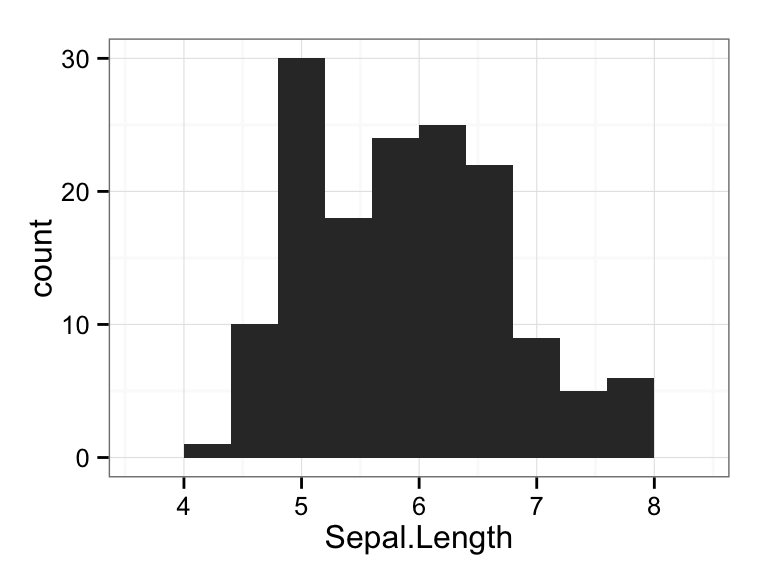

```r
# even wider bins
ggplot(iris, aes(x=Sepal.Length)) + geom_histogram(binwidth=.4)
```

*Instead of `geom_histogram()`, now use `geom_density()` and fill the area under the curves by species identity.*

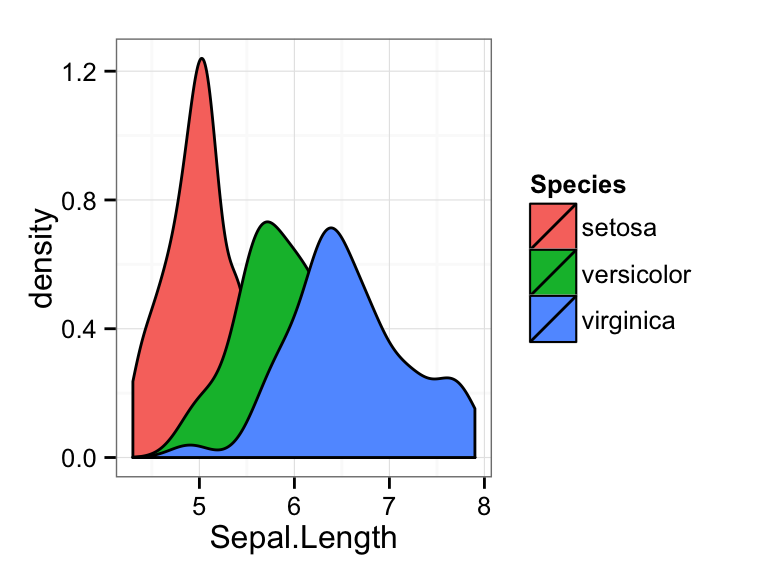

```r
ggplot(iris, aes(x=Sepal.Length, fill=Species)) + geom_density()
```

*Now make the areas under the curve partially transparent, so the overlap of the various distributions becomes clearly visible.*

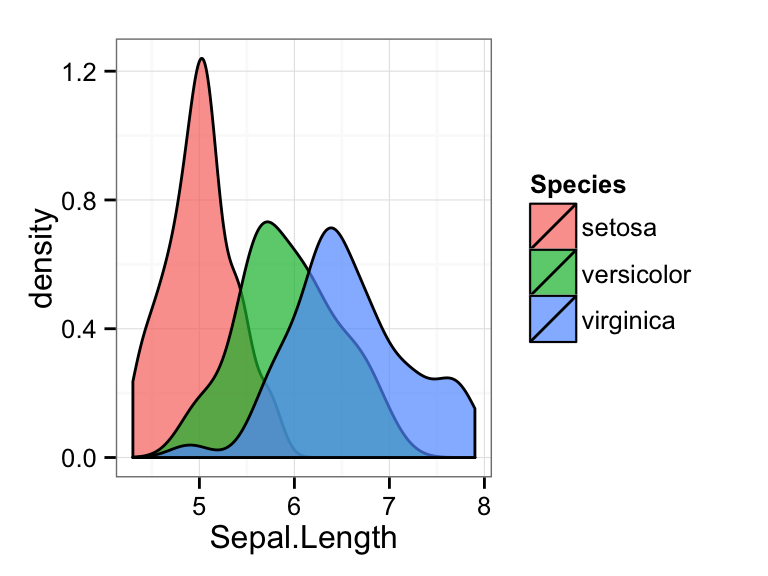

```r
ggplot(iris, aes(x=Sepal.Length, fill=Species)) + geom_density(alpha=0.7)
```

## 3. Scales

*Using the `movies` data set provided by ggplot2, make a scatter plot of the number of votes (`votes`) vs. the length of the movie (`length`). Use a log scale for both the x and the y axis.*

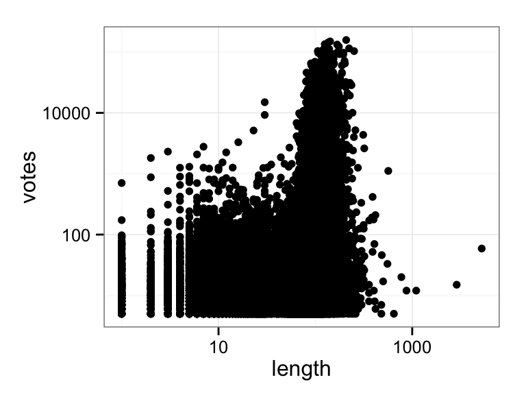

```r
ggplot(movies, aes(y=votes, x=length)) + geom_point() + scale_x_log10() + scale_y_log10()
```

*Now color the points by year and use a color gradient that goes from yellow to blue. You can change the color scale using `scale_color_gradient()`.*

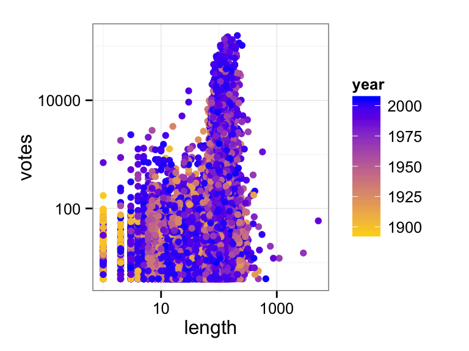

```r
ggplot(movies, aes(y=votes, x=length, color=year)) + geom_point() + scale_x_log10() + scale_y_log10() + scale_color_gradient(low='gold', high='blue')
```

*Now zoom in to movies that are between 1 and 20 minutes long, using `xlim()` instead of `scale_x_log10()`.*

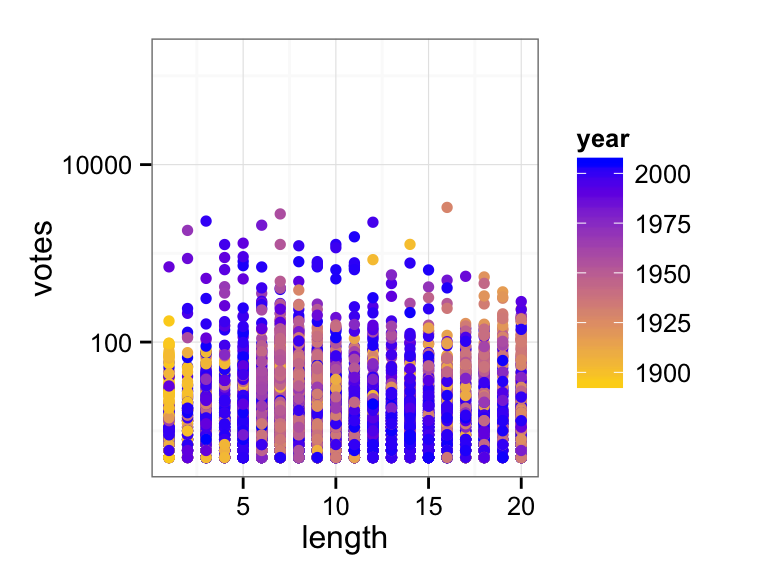

```r
ggplot(movies, aes(y=votes, x=length, color=year)) + geom_point() + xlim(1, 20) + scale_y_log10() + scale_color_gradient(low='gold', high='blue')
```

## 4. If this was easy

*Take the log-log plot of `votes` vs. `length` from the `movies` data set and plot only movies that are between 1 and 20 minutes long, but keep the log scale.*

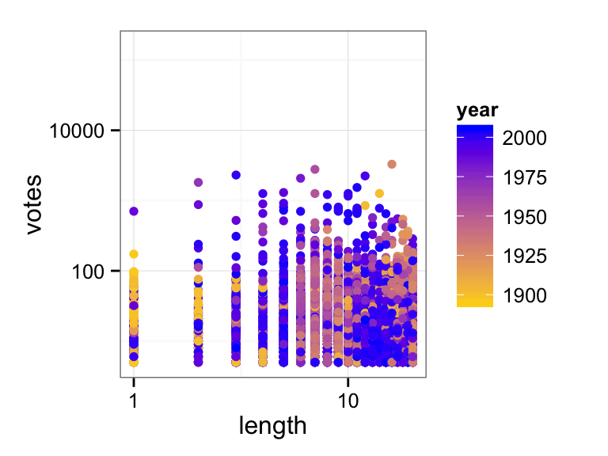

```r
ggplot(movies, aes(y=votes, x=length, color=year)) + geom_point() + scale_x_log10(limits=c(1,20)) + scale_y_log10() + scale_color_gradient(low='gold', high='blue')
```

*Make a log-log plot of `votes` vs. `length` from the `movies` data set, faceted by year. Plot a trend line onto each facet, without confidence band.*

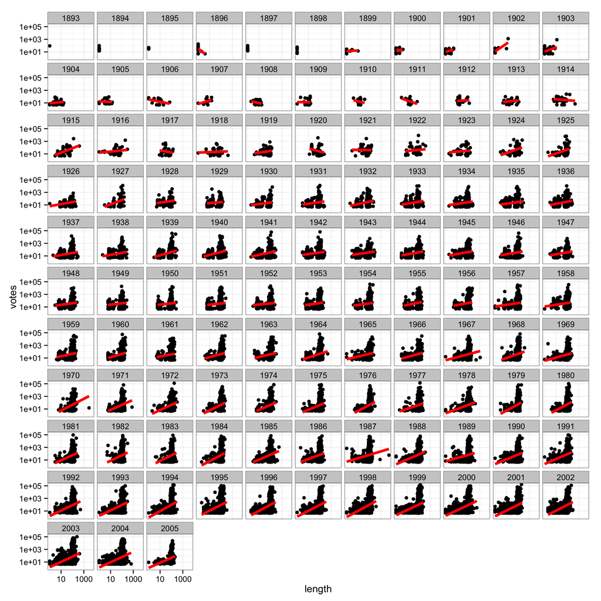

```r
ggplot(movies, aes(y=votes, x=length)) + geom_point() + geom_smooth(method='lm', se=FALSE, size=1.5, color='red') + scale_x_log10() + scale_y_log10() + facet_wrap(~year)
```

*Make a bar plot of the number of movies per year in the dataset.*

```
## stat_bin: binwidth defaulted to range/30. Use 'binwidth = x' to adjust this.
```

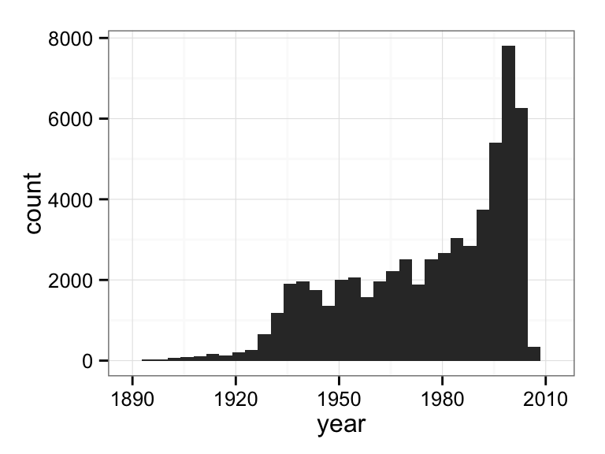

```r
ggplot(movies, aes(x=year)) + geom_bar()
```

*Go back to the `bacteria` dataset, make a bar plot that shows the total number of cases within each treatment, and plot the number of such cases on top of each bar.*

```
## ymax not defined: adjusting position using y instead
```

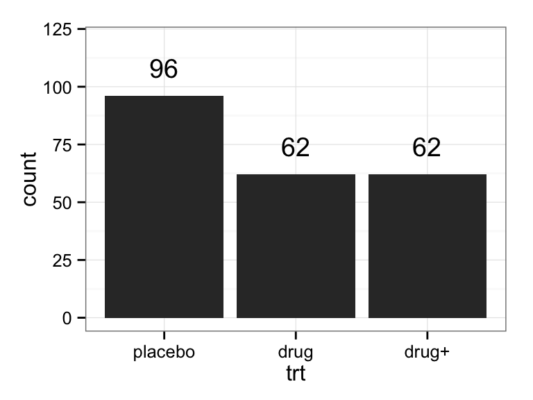

```r
ggplot(bacteria, aes(x=trt)) + geom_bar() + stat_bin(aes(label=..count..), geom="text", vjust=-1, size=5) + ylim(0, 120)
```

To plot the number of cases within each treatment, we need to count them. That count is done using `stat_bin()`, which is used by default by `geom_bar()`. However, to actually plot these numbers, we need to have direct access to them, and therefore we have to call `stat_bin()` explicitly. In the `aes()` call inside `stat_bin`, the variable `..count..` contains these counts. The two dots at the beginning and end indicate that the variable was generated by `stat_bin()` and not already present in the original dataset.